# Relatorio Final do problema 1: Responda suas perguntas

Gustavo Monteiro

26 de maio de 2017

Para o relatório final foram escolhidas duas questões:

1 - Qual das séries foi melhor avaliada em sua estreia?

Dados: Os dados examinados na questão sao avaliações de usuários dadas no IMDB a episódios de algumas séries populares. Cada observação tem o nome da série, sua temporada e seu respectivo numero nela, além de seu número de lançamento, também possui o nome do episódio e a proporção de usuários com diferentes scores, que vão de 1 a 10, que avaliaram aquele episódio e a média de avaliação dos usuários para aquele epísódio, que pode ir de 0 até 10.

```r
  best_premiere = data %>%
      group_by(series_name) %>%
      filter(season == 1) %>%
      filter(season_ep == 1) %>%
      summarise(UserRating = max(UserRating)) %>%
      top_n(1, UserRating)

  best_premiere
```

```
##   series_name UserRating
## 1    Mr Robot        9.3
```

A série que teve melhor estreia foi ‘Mr Robot’, uma avaliação do público de 9,3. Para chegar a essa resposta foram separados todos os primeiros episódios de estreia das séries e avaliado qual tinha a melhor avaliação pelo público.

Pergunta gerada: Essa marca alcançada na estreia tende a subir ou descer ao longo da primeira temporada temporada ?

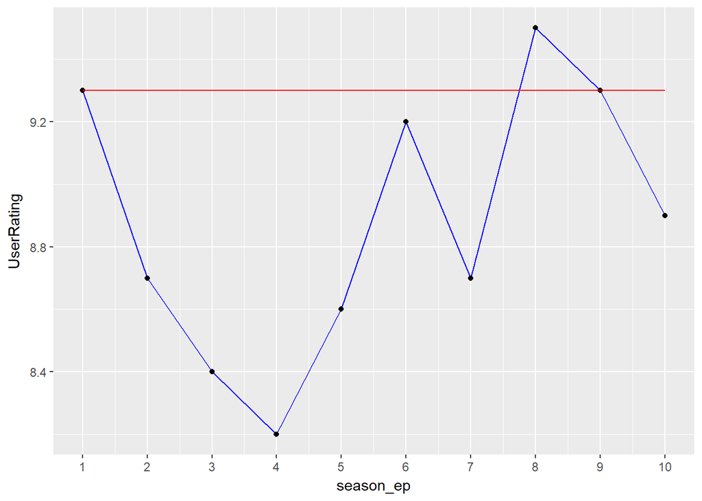

```r
   data %>%
        filter(series_name %in% c(best_premiere$series_name)) %>%
        filter(season == 1) %>%
        ggplot(aes(x =  season_ep, y = UserRating)) +
          geom_line(color="blue") +
          geom_point() +
          geom_line(aes(y = best_premiere$UserRating), color="red") +
          scale_x_continuous(breaks = seq(1, 10, 1))
```

O gráfico mostra que 7 dos outros 9 episódios da temporada tiveram uma avaliação pior que o episódio de estreia, enquanto um se iguala e apenas um supera essa marca. Com base nisso se pode afirmar que a série teve um decaimento em relação a sua avaliação da estreia com a exceção de dois episódios.

2 - Para as séries que tem mais de uma temporada, eles mantiveram seu sucesso(sua média ou mediana de avaliação) nas temporadas subsequentes.

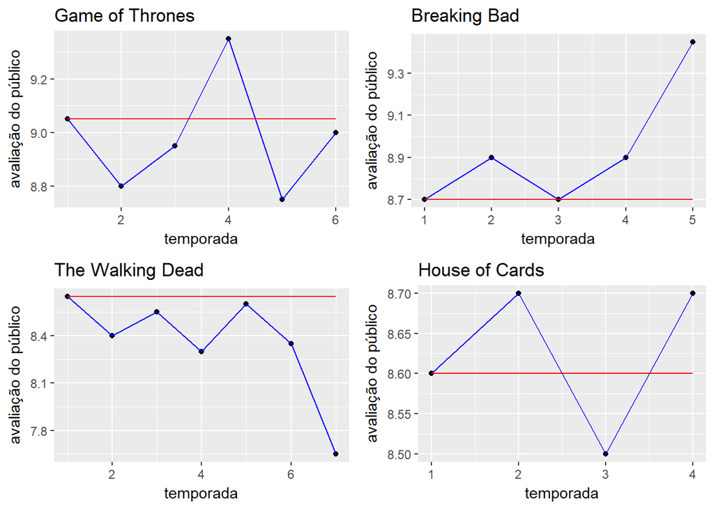

```r
  generate_plot = function(serie_name) {
    median_of_debut = data %>%
    filter(series_name %in% c(serie_name)) %>%
    filter(season == 1) %>%
    summarise(UserRating = median(UserRating))

    analisys = data %>%
      filter(series_name %in% c(serie_name)) %>%
      group_by(series_name, season) %>%
      summarise(UserRating = median(UserRating)) %>%
      ggplot(aes(x =  season, y = UserRating)) +
        geom_point() +
        geom_line(color="blue") +
        geom_line(aes(y = median_of_debut$UserRating), color="red") +
        ggtitle(serie_name) +
        labs(x="temporada", y="avaliação do público")

    return(analisys)
  }

  grid.arrange(generate_plot("Game of Thrones"), generate_plot("Breaking Bad"),
               generate_plot("The Walking Dead"), generate_plot("House of Cards"), ncol=2)
```

O gráfico mostra que isso varia de caso pra caso, para ‘The Walking Dead’ a popularidade despencou e ‘Game of Thrones’ com exceção de uma das temporadas também teve queda de popularidade, ‘House of Cards’ é bastante instável, já ‘Breaking Bad’, em geral, foi aumentado a sua popularidade.

Pergunta gerada: As séries parecem bem instáveis em sua popularidade, então qual delas é a mais consistente ?

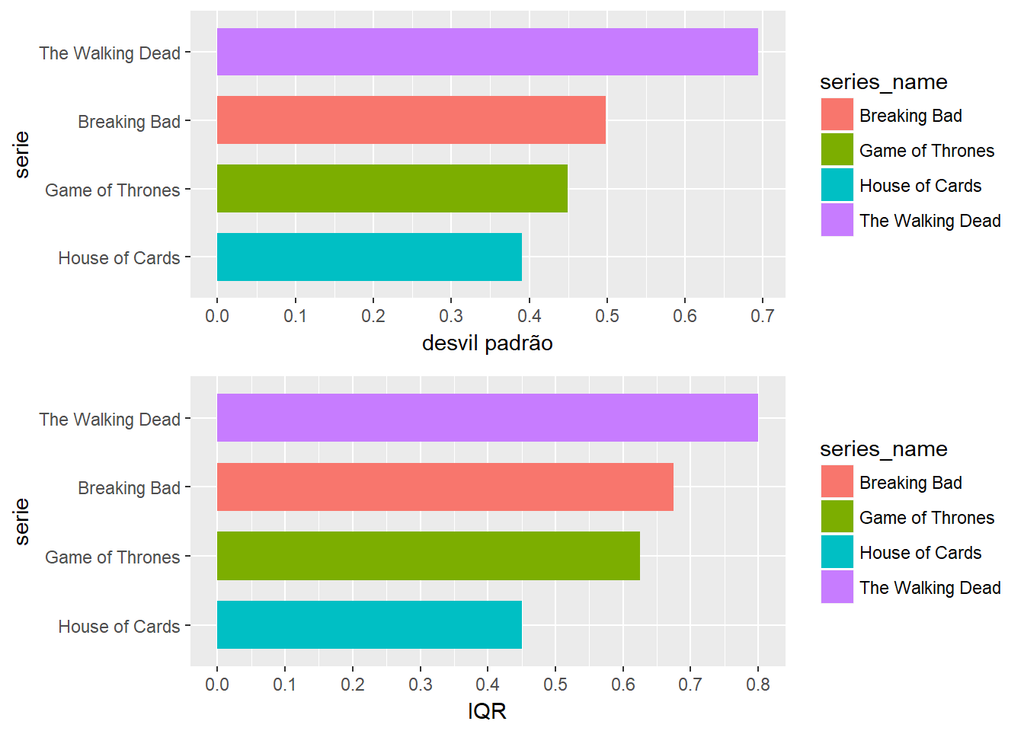

```r
  standard_deviation = data %>%
    filter(series_name %in% c("The Walking Dead", "Game of Thrones", "Breaking Bad", "House of Cards")) %>%
    group_by(series_name) %>%
    summarise(UserRating = sd(UserRating)) %>%
    ggplot(aes(x = reorder(series_name, UserRating), y = UserRating, fill = series_name)) +
      geom_col(width = 0.7) +
      scale_y_continuous(breaks=seq(0, 1, 0.1)) +
      coord_flip() +
      labs(x="serie", y="desvil padrão")

  iqr = data %>%
    filter(series_name %in% c("The Walking Dead", "Game of Thrones", "Breaking Bad", "House of Cards")) %>%
    group_by(series_name) %>%
    summarise(UserRating = IQR(UserRating)) %>%
    ggplot(aes(x = reorder(series_name, UserRating), y = UserRating, fill = series_name)) +
      geom_col(width = 0.7) +
      scale_y_continuous(breaks=seq(0, 1, 0.1)) +
      coord_flip() +
      labs(x="serie", y="IQR")

  grid.arrange(standard_deviation, iqr, ncol=1)
```

Para se chegar ao resultado foram realizados os testes de desvio padrão, que é a variação padrão em torno da média e de IQR(Interquartile Range) que é diferença entre o terceiro e primeiro quartil das observações, ela é uma medida de dispersão que representa onde estão concentrados os 50% centrais dos dados. A série que mostra ter uma popularidade mais estável é ‘House of Cards’.